# Exploring the properties of red wine

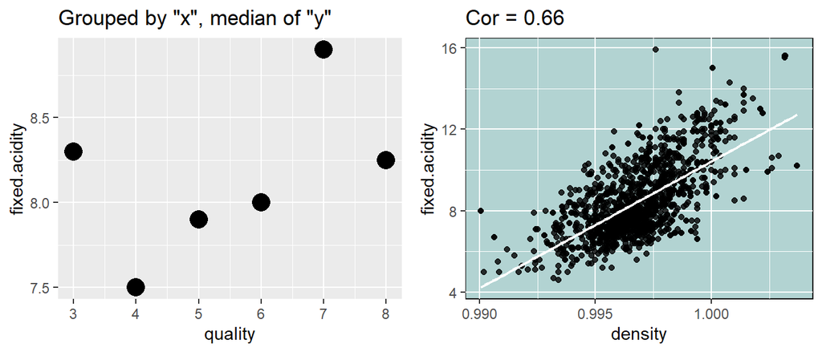

> Fixed.acidity has a strong correlation with density. A slight positive assoction from within quality can also be noted within the plot to the left.

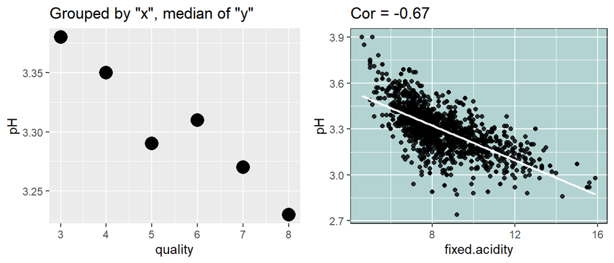

> pH as shown, has a very strong relationship with fixed.acidity. Given the nature of science, this makes sense. A negative association with quality is also noted from within the leftmost plot.

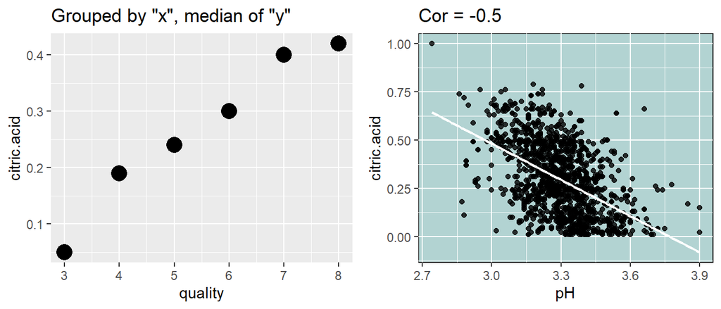

> Not suprisingly, pH has a strong correlation with another acid, citric.acid. It is starting to become clear that acidity is part of a bigger picture in determining wine quality.

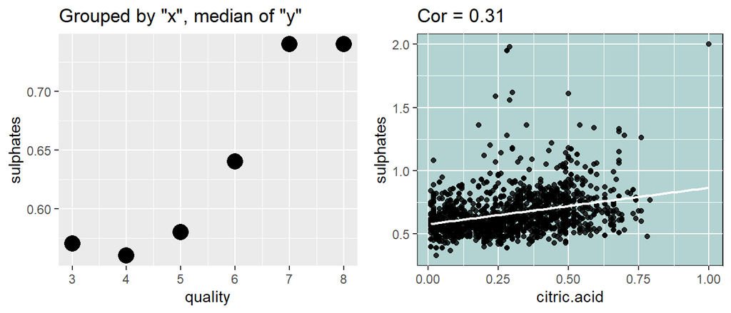

> citric.acid does not contain a lot of strong associations, however I felt I should follow the path. Sulphates appear to be of importance for high quality wines.

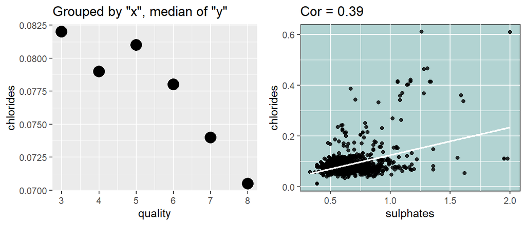

> Chlorides also did not hold a strong association from within sulphates, but it seemed to be the last within this group of possible associated variables. Of note though is the negative association from within the quality rating.

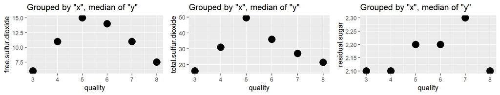

> Lastly, a quick look at the remaining variables of free/total.sulfur.dioxide and residual.sugar as compared to median values at each quality rating. Given the available data, an association withi quality is lacking from within these variables.

# Bivariate Analysis

Bivariate explorations produced some interesting findings. Initially, the quality rating did not appear to have very many strong correlations. However, in following the variable of alcohol, qualitative associations were found from within most variables. The thought of outliers was also explored within this section. Several attempts were made to expose outliers as a potential problem within modeling the data, however it appears as if these outliers do not heavily impact the trajectory of any future regression modelling.

### Relationsips among variables

Alcohol and quality do share a relationship, however it is the child relationships from within alcohol that are of the strongest from within the dataset. Not surprisingly , all of the acidic variables, and pH share a strong correlation.

### Interesting relationships

The most interesting relationship is that of density. It seems as if density falls right in the middle of alcohol and acidity levels. In essence, acting as a byproduct of the combined chemical reactions from within the other variables.

### Strongest relationship

Without surprise, the strongest relationship found is that of pH and acidity levels, strongest of which would be pH/fixed.acidity.

# Multivariate Plots Section

At a multivariate level, combining like variables would be helpful. The dataframe will be standardized to achieve these results.

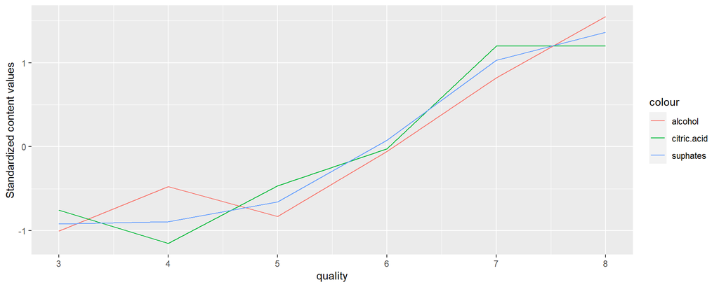

> Variables with positive quality associations are grouped by their mean at each quality rating and plotted plotted within a standardized format. These variables are strongly associated with the underlying quality rating.

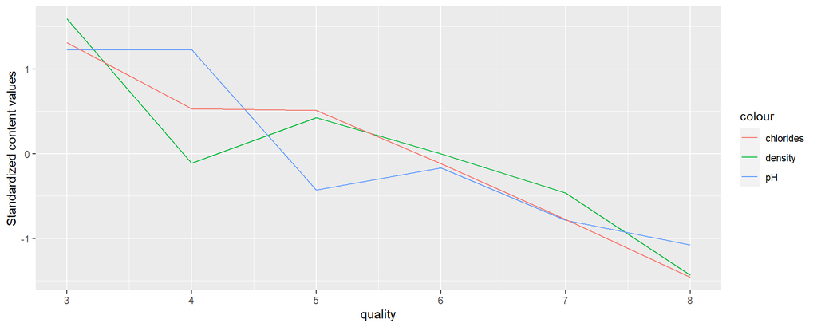

> Variables with negative quality associations are grouped by their mean at each quality rating and plotted within a standardized format. These variables are also strongly associated with the underlying quality rating.

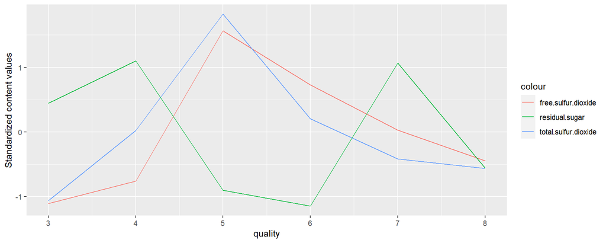

> Variables that do not show an obvious association within quality are grouped by their quality rating and plotted within a standardized format. Of interest is the appearance of an inverse quality between residual.sugar and sulfur.dioxide.

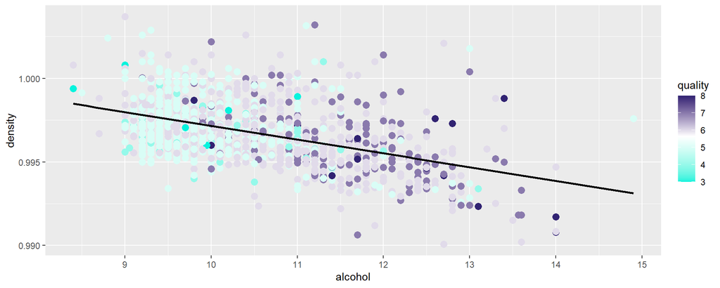

> Given the association between alchol and density, these variables are looked at within each quality rating. This shows the highest quality ratings are of higher alcohol and lower density, with quality being the variable of choice for color formatting.

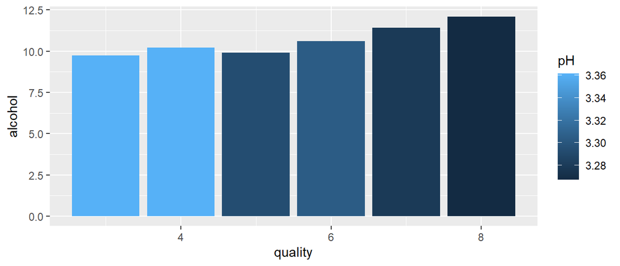

# Multivariate Analysis

### Relationships

Alcohol, density, and acidic levels all look to be decent indicators as to what quality rating a wine may be.

### Surprising interactions

Residual.sugar and its interaction within density, and alcohol was the most surprising feature I found. Although the correlation is not strong, there does seem to be some significance to the fact that sugar levels are highest among high density values.

# Final Plots and Summary

Prior observations have shown the overall unison that the majority of these variables play towards deciding the quality level of red wine. This theme will be depicted within the final plots.

### Plot One

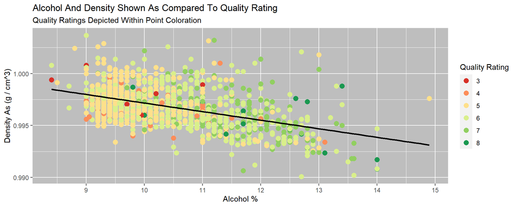

### Description One

This plot shows how alcohol percent and density work in unison to help determine the quality rating.

### Plot Two

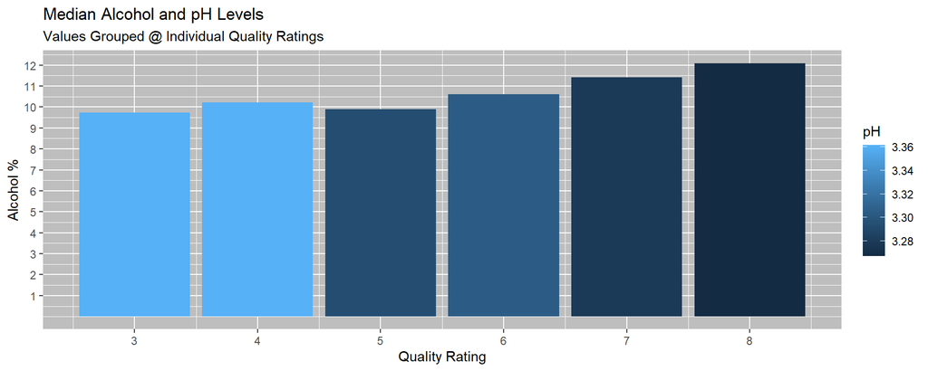

### Description Two

This is a simple but powerful representation of how acidic levels and alcohol content influence the quality rating. Higher alcohol and lower pH equate to higher quality ratings.

### Plot Three

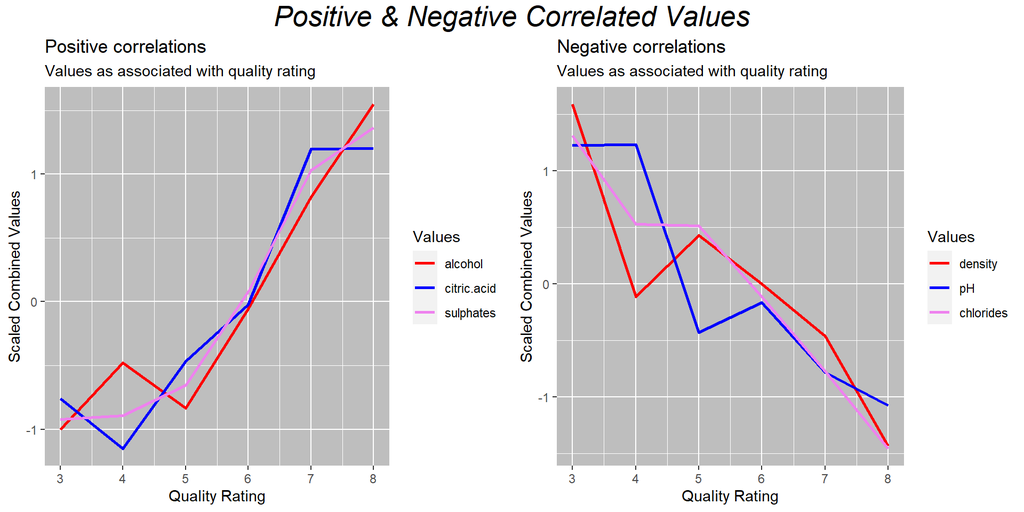

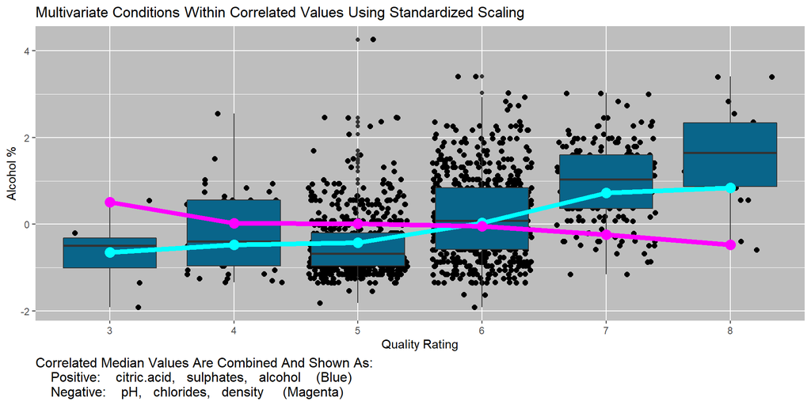

### Description Three

This is a view an overview of the most correlated variables and how they react from within the quality rating. Values have all been standardized for ease of comparison. To begin with, conditional means of positive and negative correlations are calculated and plotted individually. Lastly, these items are combined on the lower chart into two lines, one positive, and one negative. Given that alcohol is the single strongest correlated value, it is chosen for the y axis within the boxplot. With this plot, it also becomes clear how all of these variables work in unison to produce the overall result of quality.

# Reflection

The dominant correlation from within quality is alcohol. On its own, I do believe that alcohol can provide a fair level of predictability towards quality, however it should be noted that alcohol does not exist in unison. Without the remaining supporting variables, its predictability would undoubtedly diminish. I should also note that on a personal level, I do ponder the question as to why alcohol is such a strong predictor given the subjectivity of a human created quality rating system. Is this a matter of conditioning, where an individual is used to the taste of the higher alcohol and its given physiological effects, and thus ratings increase when this taste is discovered?  
Overall, the main difficulties that I ran into were that of domain knowledge. It is more difficult to trust the results when lacking a foundation of knowledge. As an example, I was unsure of the zero values from within citric acid. I was not sure if these values were possible or not, but they did seem out of place. I tested the data with and without these entries and I did not notice a significant difference without, so I did ultimately decide upon their removal.  
The primary limitations from within the dataset are from within the lack of data observations at higher and lower quality levels. It can be assumed that these ratings are unique, however a larger sample size would be nice. To achieve this, an larger overall dataset can be acquired and then randomly sampled to where all quality levels have the same number of entries.

### References

Sjoberg DD, Whiting K, Curry M, Lavery JA, Larmarange J. Reproducible summary tables with the gtsummary package. The R Journal 2021;13:570–80. https://doi.org/10.32614/RJ-2021-053.  
Winston Chang, Cookbook for R  
http://www.cookbook-r.com/